# creative_ai_day10_submission

## Assignment: Oxford Flowers 102 Image Generator using GANs

Based on the provided code for training a GAN, your assignment is to build a GAN to generate realistic flower images using the Oxford Flowers 102 dataset.

**Task:**

1. **Data Loading and Preprocessing:**
   - Ensure the code correctly loads and preprocesses the Oxford Flowers 102 dataset using `tensorflow_datasets`, resizing images to the desired `IMAGE_SHAPE` and normalizing pixel values to [-1, 1]. The current code in cell `cINCGsobBYzc` should handle this.
2. **Generator Architecture:**
   - Review and potentially modify the `build_generator` function to ensure it is suitable for generating flower images. The current architecture is designed for 128x128 images and should be a good starting point. The input will be a noise vector.
3. **Discriminator Architecture:**
   - Review and potentially modify the `build_discriminator` function. The current architecture is designed for 128x128 images and should also be a good starting point. Its role is to distinguish between real flower images from the dataset and fake flower images generated by the generator.
4. **Loss Functions and Optimizers:**
   - Ensure the `generator_loss` and `discriminator_loss` functions, and the optimizers (`gen_optimizer`, `disc_optimizer`) are correctly defined for the GAN training process. The current setup in cell `kQEmbCt7BYzd` and `lVYSVXRnBYze` should be appropriate.
5. **Training:**
   - Use the provided `train_step` and `train` functions (potentially using the distributed training setup) to train the GAN on the preprocessed Oxford Flowers 102 dataset.
6. **Evaluation and Visualization:**
   - Utilize the `generate_and_show_images` function to visualize the progress of the generator during training by generating sample flower images from a fixed noise vector.
   - After training, visually evaluate the quality and diversity of the generated flower images.

**Deliverables:**

- The modified Python notebook with the working code for the flower image generator.
- A brief report (can be a markdown section in the notebook) describing:
  - Any significant modifications made to the generator or discriminator architectures.
  - Observations during training (e.g., convergence, quality of generated images over epochs).
  - Examples of generated flower images after training.
  - Any challenges encountered during the process.

**Tips:**

- Ensure the data preprocessing correctly scales and normalizes the image data.
- Monitor the generator and discriminator losses during training to understand the GAN's progress.
- Experiment with the number of epochs to find a good balance between training time and generated image quality.
- Adjust hyperparameters like learning rates if needed.
0. **Imports & Config:**

```python
# Section 1 — Imports & Config
import os, time
import tensorflow as tf
import tensorflow_datasets as tfds
import matplotlib.pyplot as plt

# Toggle this to force CPU (e.g., for deterministic demo runs)
USE_GPU = True
if not USE_GPU:
    os.environ["CUDA_VISIBLE_DEVICES"] = "-1"

# Core config
IMAGE_SHAPE      = (128, 128, 3)   # model IO resolution
NOISE_DIM        = 100             # latent vector size
BATCH_SIZE       = 128
EPOCHS           = 25              # keeping modest for submission
STEPS_PER_EPOCH  = 500             # cap per-epoch runtime (dataset.take(...))
MAX_HOURS        = 3               # overall wall-clock budget (None to disable)

AUTOTUNE = tf.data.AUTOTUNE
```

1. **Data Loading and Preprocessing:**
   - Ensure the code correctly loads and preprocesses the Oxford Flowers 102 dataset using `tensorflow_datasets`, resizing images to the desired `IMAGE_SHAPE` and normalizing pixel values to [-1, 1]. The current code in cell `cINCGsobBYzc` should handle this.

```
One batch: (128, 128, 128, 3)
```

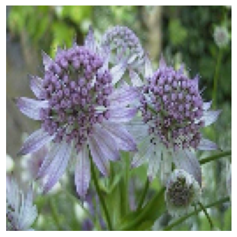

```python
# Section 1 — Data Loading & Preprocessing (TFDS -> streaming pipeline)

def preprocess_flowers(image, label=None):
    """Resize to 128x128 and normalize to [-1, 1]. Label is unused for GANs."""
    image = tf.image.resize(image, (IMAGE_SHAPE[0], IMAGE_SHAPE[1]))
    image = tf.cast(image, tf.float32)
    image = (image / 127.5) - 1.0
    return image

def build_flowers_dataset(split="train+validation+test", subset=None):
    """
    Loads Oxford Flowers 102 split from TFDS, applies preprocessing, and returns a streaming dataset.
    subset: optionally cap number of examples for faster training.
    """
    ds = tfds.load("oxford_flowers102:2.1.1", split=split, as_supervised=True)
    # as_supervised=True -> (image, label). We only need images.
    ds = ds.map(lambda x, y: preprocess_flowers(x), num_parallel_calls=AUTOTUNE)
    if subset:
        ds = ds.take(subset)
    ds = ds.shuffle(5000, reshuffle_each_iteration=True)
    ds = ds.batch(BATCH_SIZE, drop_remainder=True)
    ds = ds.prefetch(AUTOTUNE)
    return ds

# Use train split; keep subset for time-bounded demo runs
dataset = build_flowers_dataset(split="train", subset=10000)

# Quick sanity peek
sample_batch = next(iter(dataset))
print("One batch:", sample_batch.shape)  # (BATCH_SIZE, 128, 128, 3)
plt.imshow((sample_batch[0] + 1) / 2.0); plt.axis("off"); plt.show()
```

2. **Generator Architecture:**
   - Review and potentially modify the `build_generator` function to ensure it is suitable for generating flower images. The current architecture is designed for 128x128 images and should be a good starting point. The input will be a noise vector.

```python
# Section 3 — Generator (DCGAN, 128x128)
from tensorflow.keras import layers

def build_generator(noise_dim=NOISE_DIM):
    model = tf.keras.Sequential(name="Generator")
    # 1) Dense -> 8x8x512 feature map
    model.add(layers.Dense(8*8*512, use_bias=False, input_shape=(noise_dim,)))
    model.add(layers.Reshape((8, 8, 512)))
    model.add(layers.BatchNormalization()); model.add(layers.LeakyReLU())

    # 2) 8->16
    model.add(layers.Conv2DTranspose(256, (4,4), strides=2, padding="same", use_bias=False))
    model.add(layers.BatchNormalization()); model.add(layers.LeakyReLU())

    # 3) 16->32
    model.add(layers.Conv2DTranspose(128, (4,4), strides=2, padding="same", use_bias=False))
    model.add(layers.BatchNormalization()); model.add(layers.LeakyReLU())

    # 4) 32->64
    model.add(layers.Conv2DTranspose(64,  (4,4), strides=2, padding="same", use_bias=False))
    model.add(layers.BatchNormalization()); model.add(layers.LeakyReLU())

    # 5) 64->128
    model.add(layers.Conv2DTranspose(32,  (4,4), strides=2, padding="same", use_bias=False))
    model.add(layers.BatchNormalization()); model.add(layers.LeakyReLU())

    # 6) Output 128x128x3, tanh -> [-1, 1]
    model.add(layers.Conv2DTranspose(3, (4,4), strides=1, padding="same",
                                     use_bias=False, activation="tanh"))
    return model

gen = build_generator()
gen.summary()
```

```
Model: "Generator"
```

```
┏━━━━━━━━━━━━━━━━━━━━━━━━━━━━━━━━━┳━━━━━━━━━━━━━━━━━━━━━━━━┳━━━━━━━━━━━━━━━┓
┃ Layer (type)                    ┃ Output Shape           ┃       Param # ┃
┡━━━━━━━━━━━━━━━━━━━━━━━━━━━━━━━━━╇━━━━━━━━━━━━━━━━━━━━━━━━╇━━━━━━━━━━━━━━━┩
│ dense_25 (Dense)                │ (None, 32768)          │     3,276,800 │
├─────────────────────────────────┼────────────────────────┼───────────────┤
│ reshape_12 (Reshape)            │ (None, 8, 8, 512)      │             0 │
├─────────────────────────────────┼────────────────────────┼───────────────┤
│ batch_normalization_60          │ (None, 8, 8, 512)      │         2,048 │
│ (BatchNormalization)            │                        │               │
├─────────────────────────────────┼────────────────────────┼───────────────┤
│ leaky_re_lu_112 (LeakyReLU)     │ (None, 8, 8, 512)      │             0 │
├─────────────────────────────────┼────────────────────────┼───────────────┤
│ conv2d_transpose_60             │ (None, 16, 16, 256)    │     2,097,152 │
│ (Conv2DTranspose)               │                        │               │
├─────────────────────────────────┼────────────────────────┼───────────────┤
│ batch_normalization_61          │ (None, 16, 16, 256)    │         1,024 │
│ (BatchNormalization)            │                        │               │
├─────────────────────────────────┼────────────────────────┼───────────────┤
│ leaky_re_lu_113 (LeakyReLU)     │ (None, 16, 16, 256)    │             0 │
├─────────────────────────────────┼────────────────────────┼───────────────┤
│ conv2d_transpose_61             │ (None, 32, 32, 128)    │       524,288 │
│ (Conv2DTranspose)               │                        │               │
├─────────────────────────────────┼────────────────────────┼───────────────┤
│ batch_normalization_62          │ (None, 32, 32, 128)    │           512 │
│ (BatchNormalization)            │                        │               │
├─────────────────────────────────┼────────────────────────┼───────────────┤
│ leaky_re_lu_114 (LeakyReLU)     │ (None, 32, 32, 128)    │             0 │
├─────────────────────────────────┼────────────────────────┼───────────────┤
│ conv2d_transpose_62             │ (None, 64, 64, 64)     │       131,072 │
│ (Conv2DTranspose)               │                        │               │
├─────────────────────────────────┼────────────────────────┼───────────────┤
│ batch_normalization_63          │ (None, 64, 64, 64)     │           256 │
│ (BatchNormalization)            │                        │               │
├─────────────────────────────────┼────────────────────────┼───────────────┤
│ leaky_re_lu_115 (LeakyReLU)     │ (None, 64, 64, 64)     │             0 │
├─────────────────────────────────┼────────────────────────┼───────────────┤
│ conv2d_transpose_63             │ (None, 128, 128, 32)   │        32,768 │
│ (Conv2DTranspose)               │                        │               │
├─────────────────────────────────┼────────────────────────┼───────────────┤
│ batch_normalization_64          │ (None, 128, 128, 32)   │           128 │
│ (BatchNormalization)            │                        │               │
├─────────────────────────────────┼────────────────────────┼───────────────┤
│ leaky_re_lu_116 (LeakyReLU)     │ (None, 128, 128, 32)   │             0 │
├─────────────────────────────────┼────────────────────────┼───────────────┤
│ conv2d_transpose_64             │ (None, 128, 128, 3)    │         1,536 │
│ (Conv2DTranspose)               │                        │               │
└─────────────────────────────────┴────────────────────────┴───────────────┘
```

```
 Total params: 6,067,584 (23.15 MB)
```

```
 Trainable params: 6,065,600 (23.14 MB)
```

```
 Non-trainable params: 1,984 (7.75 KB)
```

3. **Discriminator Architecture:**
   - Review and potentially modify the `build_discriminator` function. The current architecture is designed for 128x128 images and should also be a good starting point. Its role is to distinguish between real flower images from the dataset and fake flower images generated by the generator.

```python
# Section 3 — Discriminator (DCGAN, 128x128)
def build_discriminator():
    model = tf.keras.Sequential(name="Discriminator")
    # 128 -> 64
    model.add(layers.Conv2D(64, (4,4), strides=2, padding="same", input_shape=(128,128,3)))
    model.add(layers.LeakyReLU(0.2)); model.add(layers.Dropout(0.3))

    # 64 -> 32
    model.add(layers.Conv2D(128, (4,4), strides=2, padding="same"))
    model.add(layers.LeakyReLU(0.2)); model.add(layers.Dropout(0.3))

    # 32 -> 16
    model.add(layers.Conv2D(256, (4,4), strides=2, padding="same"))
    model.add(layers.LeakyReLU(0.2)); model.add(layers.Dropout(0.3))

    # 16 -> 8
    model.add(layers.Conv2D(512, (4,4), strides=2, padding="same"))
    model.add(layers.LeakyReLU(0.2)); model.add(layers.Dropout(0.3))

    model.add(layers.Flatten())
    model.add(layers.Dense(1))  # raw logit
    return model

disc = build_discriminator()
disc.summary()
```

```
Model: "Discriminator"
```

```
┏━━━━━━━━━━━━━━━━━━━━━━━━━━━━━━━━━┳━━━━━━━━━━━━━━━━━━━━━━━━┳━━━━━━━━━━━━━━━┓
┃ Layer (type)                    ┃ Output Shape           ┃       Param # ┃
┡━━━━━━━━━━━━━━━━━━━━━━━━━━━━━━━━━╇━━━━━━━━━━━━━━━━━━━━━━━━╇━━━━━━━━━━━━━━━┩
│ conv2d_52 (Conv2D)              │ (None, 64, 64, 64)     │         3,136 │
├─────────────────────────────────┼────────────────────────┼───────────────┤
│ leaky_re_lu_117 (LeakyReLU)     │ (None, 64, 64, 64)     │             0 │
├─────────────────────────────────┼────────────────────────┼───────────────┤
│ dropout_52 (Dropout)            │ (None, 64, 64, 64)     │             0 │
├─────────────────────────────────┼────────────────────────┼───────────────┤
│ conv2d_53 (Conv2D)              │ (None, 32, 32, 128)    │       131,200 │
├─────────────────────────────────┼────────────────────────┼───────────────┤
│ leaky_re_lu_118 (LeakyReLU)     │ (None, 32, 32, 128)    │             0 │
├─────────────────────────────────┼────────────────────────┼───────────────┤
│ dropout_53 (Dropout)            │ (None, 32, 32, 128)    │             0 │
├─────────────────────────────────┼────────────────────────┼───────────────┤
│ conv2d_54 (Conv2D)              │ (None, 16, 16, 256)    │       524,544 │
├─────────────────────────────────┼────────────────────────┼───────────────┤
│ leaky_re_lu_119 (LeakyReLU)     │ (None, 16, 16, 256)    │             0 │
├─────────────────────────────────┼────────────────────────┼───────────────┤
│ dropout_54 (Dropout)            │ (None, 16, 16, 256)    │             0 │
├─────────────────────────────────┼────────────────────────┼───────────────┤
│ conv2d_55 (Conv2D)              │ (None, 8, 8, 512)      │     2,097,664 │
├─────────────────────────────────┼────────────────────────┼───────────────┤
│ leaky_re_lu_120 (LeakyReLU)     │ (None, 8, 8, 512)      │             0 │
├─────────────────────────────────┼────────────────────────┼───────────────┤
│ dropout_55 (Dropout)            │ (None, 8, 8, 512)      │             0 │
├─────────────────────────────────┼────────────────────────┼───────────────┤
│ flatten_13 (Flatten)            │ (None, 32768)          │             0 │
├─────────────────────────────────┼────────────────────────┼───────────────┤
│ dense_26 (Dense)                │ (None, 1)              │        32,769 │
└─────────────────────────────────┴────────────────────────┴───────────────┘
```

```
 Total params: 2,789,313 (10.64 MB)
```

```
 Trainable params: 2,789,313 (10.64 MB)
```

```
 Non-trainable params: 0 (0.00 B)
```

4. **Loss Functions and Optimizers:**
   - Ensure the `generator_loss` and `discriminator_loss` functions, and the optimizers (`gen_optimizer`, `disc_optimizer`) are correctly defined for the GAN training process. The current setup in cell `kQEmbCt7BYzd` and `lVYSVXRnBYze` should be appropriate.

```python
# Section 4 — Strategy + Losses/Optimizers + Checkpoints (+ Resume)

# a) Strategy
try:
    strategy = tf.distribute.MirroredStrategy()
    print("Replicas:", strategy.num_replicas_in_sync)
except Exception:
    strategy = tf.distribute.get_strategy()
    print("Using default strategy.")

with strategy.scope():
    # b) Models
    generator     = build_generator()
    discriminator = build_discriminator()

    # c) Losses & Optimizers
    cross_entropy = tf.keras.losses.BinaryCrossentropy(from_logits=True)

    def generator_loss(fake_logits):
        # Generator wants fake to be classified as real (ones)
        return cross_entropy(tf.ones_like(fake_logits), fake_logits)

    def discriminator_loss(real_logits, fake_logits):
        # Discriminator wants real->1, fake->0
        real_loss = cross_entropy(tf.ones_like(real_logits), real_logits)
        fake_loss = cross_entropy(tf.zeros_like(fake_logits), fake_logits)
        return real_loss + fake_loss

    gen_optimizer  = tf.keras.optimizers.Adam(1e-4)
    disc_optimizer = tf.keras.optimizers.Adam(1e-4)

# d) Distribute dataset (multi-GPU aware; no-op on single device)
dist_dataset = strategy.experimental_distribute_dataset(dataset)

# e) Checkpoints (weights + optimizer state)
from pathlib import Path
CKPT_DIR = Path("./flowers_gan_ckpts"); CKPT_DIR.mkdir(exist_ok=True)
gen_ckpt  = tf.train.Checkpoint(optimizer=gen_optimizer,  model=generator)
disc_ckpt = tf.train.Checkpoint(optimizer=disc_optimizer, model=discriminator)
gen_mgr   = tf.train.CheckpointManager(gen_ckpt,  str(CKPT_DIR / "gen"),  max_to_keep=5)
disc_mgr  = tf.train.CheckpointManager(disc_ckpt, str(CKPT_DIR / "disc"), max_to_keep=5)

# f) 🔁 Resume from latest checkpoints if available
if gen_mgr.latest_checkpoint:
    print(f"🔁 Restoring generator from {gen_mgr.latest_checkpoint}")
    gen_ckpt.restore(gen_mgr.latest_checkpoint)
else:
    print("🆕 Starting generator from scratch.")

if disc_mgr.latest_checkpoint:
    print(f"🔁 Restoring discriminator from {disc_mgr.latest_checkpoint}")
    disc_ckpt.restore(disc_mgr.latest_checkpoint)
else:
    print("🆕 Starting discriminator from scratch.")
```

```
INFO:tensorflow:Using MirroredStrategy with devices ('/job:localhost/replica:0/task:0/device:CPU:0',)
```

```
INFO:tensorflow:Using MirroredStrategy with devices ('/job:localhost/replica:0/task:0/device:CPU:0',)
```

```
Replicas: 1
🔁 Restoring generator from flowers_gan_ckpts\gen\ckpt-50
🔁 Restoring discriminator from flowers_gan_ckpts\disc\ckpt-50
```

5. **Training:**
   - Use the provided `train_step` and `train` functions (potentially using the distributed training setup) to train the GAN on the preprocessed Oxford Flowers 102 dataset.

```python
# Section 5 — Train Step (+ distributed wrapper) & Preview
import numpy as np
from IPython.display import clear_output

def generate_and_show_images(noise):
    """Plot an N-sample grid from a noise batch; works inside training loop."""
    # ensure noise is a batch (N, NOISE_DIM)
    if len(noise.shape) == 1:
        noise = tf.expand_dims(noise, 0)

    preds = generator(noise, training=False)
    preds = (preds + 1) / 2.0  # back to [0,1]

    n = preds.shape[0]
    rows = int(np.ceil(np.sqrt(n)))
    cols = int(np.ceil(n / rows))

    clear_output(wait=True)  # avoid stacking figures in notebooks
    fig, axes = plt.subplots(rows, cols, figsize=(cols*2.2, rows*2.2))
    axes = np.array(axes).reshape(-1)
    for i in range(rows * cols):
        axes[i].axis("off")
        if i < n:
            axes[i].imshow(preds[i])
    plt.tight_layout()
    plt.show()

GLOBAL_BATCH_SIZE = BATCH_SIZE

GLOBAL_BATCH_SIZE = BATCH_SIZE

@tf.function
def train_step(real_images):
    noise = tf.random.normal([GLOBAL_BATCH_SIZE, NOISE_DIM])

    with tf.GradientTape() as g_tape, tf.GradientTape() as d_tape:
        fake_images = generator(noise, training=True)
        real_logits = discriminator(real_images, training=True)
        fake_logits = discriminator(fake_images, training=True)

        g_loss = generator_loss(fake_logits)
        d_loss = discriminator_loss(real_logits, fake_logits)

    g_grads = g_tape.gradient(g_loss, generator.trainable_variables)
    d_grads = d_tape.gradient(d_loss, discriminator.trainable_variables)
    gen_optimizer.apply_gradients(zip(g_grads, generator.trainable_variables))
    disc_optimizer.apply_gradients(zip(d_grads, discriminator.trainable_variables))
    return g_loss, d_loss

@tf.function
def distributed_train_step(batch):
    per_replica_g, per_replica_d = strategy.run(train_step, args=(batch,))
    mean_g = strategy.reduce(tf.distribute.ReduceOp.MEAN, per_replica_g, axis=None)
    mean_d = strategy.reduce(tf.distribute.ReduceOp.MEAN, per_replica_d, axis=None)
    return mean_g, mean_d
```

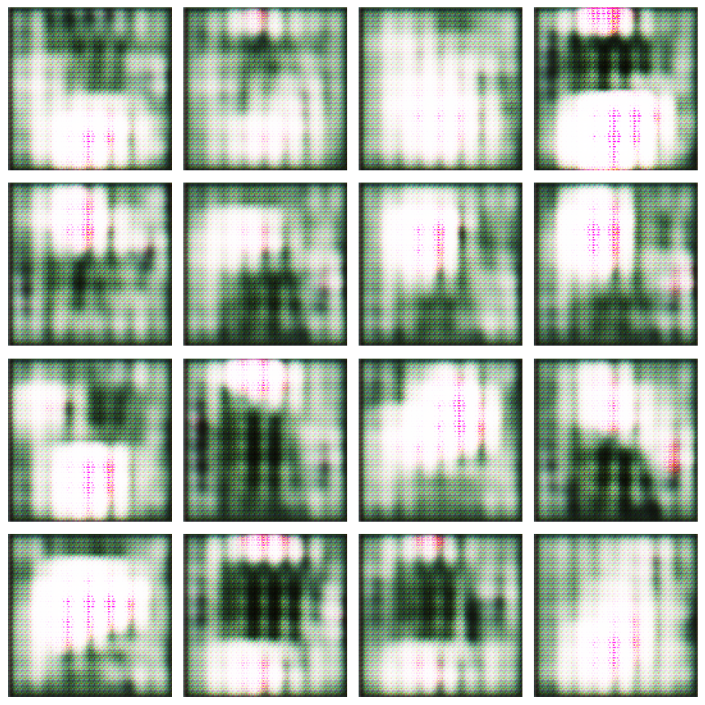

```python
# Section 5 — Training Loop (bounded by steps & wall-clock time)

def train(dist_dataset, epochs, steps_per_epoch=STEPS_PER_EPOCH, max_hours=MAX_HOURS):
    # use a BATCH of noise so previews show a grid (e.g., 16 images)
    fixed_noise = tf.random.normal([16, NOISE_DIM])
    end_time = (time.time() + max_hours*3600) if max_hours else None

    for epoch in range(epochs):
        # epoch-level time check
        if end_time and time.time() >= end_time:
            print("⏱️ Time budget reached. Stopping."); break

        g_losses, d_losses = [], []
        t0 = time.time()

        # iterate and cap steps per epoch
        for step, real_batch in enumerate(dist_dataset, start=1):
            # mid-epoch time check
            if end_time and time.time() >= end_time:
                print("⏱️ Time budget reached mid-epoch. Stopping.")
                return

            g_loss, d_loss = distributed_train_step(real_batch)
            g_losses.append(g_loss); d_losses.append(d_loss)

            if step >= steps_per_epoch:
                break

        avg_g = float(tf.reduce_mean(g_losses))
        avg_d = float(tf.reduce_mean(d_losses))
        print(f"Epoch {epoch+1}/{epochs} | G: {avg_g:.4f}  D: {avg_d:.4f} | {time.time()-t0:.1f}s")

        # preview every 2 epochs (shows a grid)
        # if (epoch+1) % 2 == 0:
        #     generate_and_show_images(fixed_noise)

        generate_and_show_images(fixed_noise)

        # save checkpoints each epoch
        gen_mgr.save(); disc_mgr.save()

# ---- Run training ----
train(dist_dataset, EPOCHS, steps_per_epoch=STEPS_PER_EPOCH, max_hours=MAX_HOURS)
```

6. **Evaluation and Visualization:**
   - Utilize the `generate_and_show_images` function to visualize the progress of the generator during training by generating sample flower images from a fixed noise vector.
   - After training, visually evaluate the quality and diversity of the generated flower images.

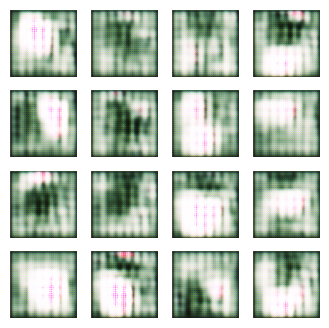

```python
# Section 6 — Extra Evaluation (new random samples)
def show_grid_from_random(noise_dim=NOISE_DIM, n=16):
    noise = tf.random.normal([n, noise_dim])
    preds = generator(noise, training=False)
    preds = (preds + 1) / 2.0
    fig = plt.figure(figsize=(4,4))
    for i in range(n):
        plt.subplot(4,4,i+1); plt.imshow(preds[i]); plt.axis("off")
    plt.show()

show_grid_from_random()
```